# STELLAR Engine: knowledge base

NSF Regional Innovation Engines, Cohort 2. Technology profile v3.1. Draft, in progress

**NSF STELLAR Engine in the Rochester/Finger Lakes Region of New York**, led by University of Rochester. NSF award 2532428, start August 2026. Search window for papers and patents: from August 2021 (five years before the award) onward.

## At a glance

| Measure | Value |
| --- | --- |
| People named by NSF or the Engine’s site | 15 |
| of them active researchers (>= 5 works since window start) | 4 |
| Team members who are inventors (2021-2025 grants, in the region) | 4 |
| Partners (site list + team members’ organisations) | 87 |
| Knowledge-producer partners (universities, labs, institutes) | 6 |
| Partner papers in the Engine’s topics | 1188 |
| of them with an in-region partner | 385 |
| Regional patents in the technology profile (2021-2025 grants) | 220 |
| Location quotient of the technology profile (patents) | 2.79 |
| Share of regional technology patents owned by partners | 30.9% |

## Economic base

| NAICS | Industry | Employment in region | Establishments | Share of US employment | Employment LQ |
| --- | --- | --- | --- | --- | --- |
| 3333 | Commercial and service industry machinery (incl. optical instruments and lenses) | 2,345 | 25 | 2.9% | 7.95 |
| 3344 | Semiconductor and other electronic components | 1,175 | 16 | 0.4% | 1.15 |
| 3345 | Navigational, measuring, electromedical and control instruments | 2,217 | 32 | 0.5% | 1.46 |

Industries related to the Engine’s technology (chosen from the NSF abstract, see `data/manual/engine_naics.csv`). County Business Patterns 2023; LQ = the industry’s share of regional employment relative to its share of US employment (1 = US average). Region: 11 of 11.

## Technology profile

Version 3.1, core. The NSF abstract names 3 technologies of this Engine (scientific and technical fragments extracted with a fixed prompt; the extraction was done by hand in a chat session, not reproducible). For each technology, all 4,516 OpenAlex topics and all CPC main groups are ranked by several independent signals; the core keeps up to 2 topics and 2 CPC main groups per technology. *Judge*: chosen by a rubric judge where no candidate was confirmed by two kinds of evidence (also by hand in a chat session). An empty cell: no suitable item among the candidates. See Methodology and the comparison of versions.

| # | Technology | OpenAlex topics | CPC main groups |
| --- | --- | --- | --- |
| 1 | precision-optics and imaging | T10638 Optical measurement and interference techniques T11517 Advanced optical system design | G02B27/00 Optical systems or apparatus not provided for by any of the groups G02B1/00 - G02B26/00, G02B30/00 G01B9/00 Measuring instruments characterised by the use of optical techniques |
| 2 | photonics and laser technologies | T14158 Optical Systems and Laser Technology T11429 Semiconductor Lasers and Optical Devices | H01S3/00 Lasers, i.e. devices using stimulated emission of electromagnetic radiation in the infrared, visible or ultraviolet wave range |
| 3 | laser component and system manufacturing | T14158 Optical Systems and Laser Technology | H01S3/00 Lasers, i.e. devices using stimulated emission of electromagnetic radiation in the infrared, visible or ultraviolet wave range (judge) H01S5/00 Semiconductor lasers (judge) |

## People

| Role | People |
| --- | --- |
| organizer | 10 |
| researcher | 5 |

| Name | Role | On NSF award | Title | Organisation | Works since window (in Engine topics) | h-index | Patents 2021-25 (in Engine profile) | Site | OpenAlex |
| --- | --- | --- | --- | --- | --- | --- | --- | --- | --- |
| Alexis Vogt | researcher | Co-PI | Co-PI / Education and Workforce Development | Monroe Community College and New York… | 16 (0) | 3 |  | [page](https://stellarlasers.org/leadership/) | [profile](https://openalex.org/A5065159453) |
| Jonathan Zuegel | researcher |  | Co-I / Extreme Laser R&D | Laboratory for Laser Energetics | 27 (8) | 45 | 1 (0) | [page](https://stellarlasers.org/leadership/) | [profile](https://openalex.org/A5033064200) |
| Stefan Preble | researcher | Co-PI | Co-PI / R&D Coordination and Higher Education Workforce D… | Rochester Institute of Technology | 69 (14) | 22 | 2 (0) | [page](https://stellarlasers.org/leadership/) | [profile](https://openalex.org/A5050560685) |
| Susan Houde-Walter | researcher |  | Director, Professor, CEO, Advisor | University of Arizona | - | - | 6 (1) | [page](https://stellarlasers.org/advisory-board/) |  |
| Thomas G. Brown | researcher | PI | Co-PI / CTO | University of Rochester | 32 (10) | 31 | 1 (0) | [page](https://stellarlasers.org/leadership/) | [profile](https://openalex.org/A5005557212) |
| Dustin Newman | organizer |  |  | University of Rochester, Institute of… | - | - |  | [page](https://stellarlasers.org/leadership/) |  |
| Jenifer Bunis | organizer |  | Principal | Westlake Photonics | - | - |  | [page](https://stellarlasers.org/advisory-board/) |  |
| Josanne DeNatale | organizer |  | Co-I / Education and Workforce Development | FocusPath Consulting | - | - |  | [page](https://stellarlasers.org/leadership/) |  |
| Joseph Spilman | organizer |  | CEO | Optimax | - | - |  | [page](https://stellarlasers.org/advisory-board/) |  |
| Leah George VanScott | organizer | Co-PI | Co-PI / Economic Development and Regional Coordination | Greater Rochester Enterprise | - | - |  | [page](https://stellarlasers.org/leadership/) |  |
| Mark Tolbert | organizer |  | President & CEO | TOPTICA Photonics | - | - |  | [page](https://stellarlasers.org/advisory-board/) |  |
| N. Darius Sankey | organizer |  | Venture Capital and IP Management | Innovation Acceleration Capital | - | - |  | [page](https://stellarlasers.org/leadership/) |  |
| Natalie Antal | organizer |  | Director of Communications and Operations | NSF STELLAR Engine | - | - |  | [page](https://stellarlasers.org/leadership/) |  |
| Sujatha Ramanujan | organizer | Co-PI | CEO | NSF STELLAR Engine | - | - |  | [page](https://stellarlasers.org/leadership/) |  |
| Turan Erdogan | organizer |  | President | Plymouth Grating Laboratory, Inc. | - | - |  | [page](https://stellarlasers.org/advisory-board/) |  |

Publication counts are shown only where the OpenAlex author matches both the name and the person’s current organisation. The OpenAlex link is given only for these reliable matches, and not for profiles flagged as possibly merging several namesakes. *Site* links to the page of the Engine’s website where the person is named. Click a number of works to see the list on the Publications page. *Patents*: US grants 2021-2025 with the person among the inventors (same last and first name, address in the Engine’s states); click the number for the list on the Patents page. In brackets: works in the Engine’s topics, patents with a CPC code in the Engine’s technology profile.

## Researchers at partner organisations

| # | Researcher | Partner | Works in the Engine’s topics | Citations | Years | Most cited of these works |
| --- | --- | --- | --- | --- | --- | --- |
| 1 | [Jannick P. Rolland](https://openalex.org/A5004153189) | University of Rochester | 49 | 222 | 2021-2026 | [Waveguide-based augmented reality displays: a highlight](https://openalex.org/W4390988584) |
| 2 | [Julie Bentley](https://openalex.org/A5108402666) | University of Rochester | 34 | 96 | 2021-2026 | [Freeform gradient-index media: a new frontier in freeform…](https://openalex.org/W3206207128) |
| 3 | [Qiang Lin](https://openalex.org/A5108635429) | University of Rochester | 19 | 375 | 2022-2025 | [Integrated Pockels laser](https://openalex.org/W4224980528) |
| 4 | [Aaron M. Bauer](https://openalex.org/A5012151387) | University of Rochester | 18 | 138 | 2021-2026 | [Freeform hyperspectral imager design in a CubeSat format](https://openalex.org/W3205406589) |
| 5 | [Shixin Xue](https://openalex.org/A5074324544) | University of Rochester | 16 | 301 | 2022-2026 | [Integrated Pockels laser](https://openalex.org/W4224980528) |
| 6 | [Jeremy Staffa](https://openalex.org/A5003427008) | University of Rochester | 15 | 368 | 2022-2026 | [Integrated Pockels laser](https://openalex.org/W4224980528) |
| 7 | [Greg R. Schmidt](https://openalex.org/A5071164041) | University of Rochester | 15 | 89 | 2021-2025 | [Freeform gradient-index media: a new frontier in freeform…](https://openalex.org/W3206207128) |
| 8 | [Duncan T. Moore](https://openalex.org/A5007739968) | University of Rochester | 15 | 85 | 2021-2025 | [Freeform gradient-index media: a new frontier in freeform…](https://openalex.org/W3206207128) |
| 9 | [Matthew Seitz](https://openalex.org/A5002205735) | Rochester Institute of Technology | 15 | 39 | 2022-2026 | [Inverse Tapered AlGaN Micropillar and Nanowire LEDs for I…](https://openalex.org/W4310054177) |
| 10 | [Jingwei Ling](https://openalex.org/A5052561561) | University of Rochester | 13 | 361 | 2022-2025 | [Integrated Pockels laser](https://openalex.org/W4224980528) |
| 11 | [Susana C. Marcos](https://openalex.org/A5048647453) | University of Rochester | 13 | 51 | 2021-2026 | [Design concepts for advanced-technology intraocular lense…](https://openalex.org/W4405015748) |
| 12 | [Daniel K. Nikolov](https://openalex.org/A5072282448) | University of Rochester | 13 | 15 | 2021-2026 | [Framework for optimizing AR waveguide in-coupler architec…](https://openalex.org/W4391954255) |
| 13 | [Raymond Lopez‐Rios](https://openalex.org/A5091150175) | University of Rochester | 12 | 362 | 2022-2026 | [Integrated Pockels laser](https://openalex.org/W4224980528) |
| 14 | [Stefan F. Preble](https://openalex.org/A5050560685) (team) | Rochester Institute of Technology | 12 | 118 | 2022-2026 | [Petabit-Scale Silicon Photonic Interconnects With Integra…](https://openalex.org/W4294766881) |
| 15 | [Zhengdong Gao](https://openalex.org/A5060230766) | University of Rochester | 11 | 97 | 2023-2025 | [Electrically empowered microcomb laser](https://openalex.org/W4397010117) |

The grant names mostly managers; the technology is often developed at the partner universities and labs. These are the authors with the most works in the Engine’s OpenAlex topics written at a knowledge-producer partner in the Engine’s states, since the window start (at least 3 works; top 15). The list depends on the technology profile version. OpenAlex sometimes merges namesakes into one author: check the profile before relying on a name.

## Partners

| Organisation class | Partners |
| --- | --- |
| company | 52 |
| intermediary | 9 |
| government | 7 |
| k12_education | 7 |
| community_college | 4 |
| university | 4 |
| national_lab | 2 |
| investor | 1 |
| philanthropy | 1 |

Partner list on the site: *Complete (76 collaborators + 8 coalition leadership organisations; names from logo files)*.

| Partner | Class | State | OpenAlex works since window (all topics) |
| --- | --- | --- | --- |
| University of Arizona | university | Arizona | 76106 |
| University of Rochester | university | New York | 38264 |
| Lawrence Livermore National Laboratory | national_lab | California | 35861 |
| Rochester Institute of Technology | university | New York | 9215 |
| Laboratory for Laser Energetics | national_lab | New York | 1011 |
| SUNY Geneseo | university | New York | 664 |

## Science base: partner papers in the Engine’s topics

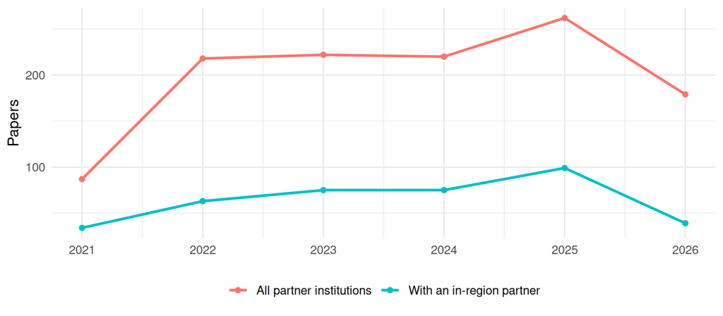

| Partner | Papers in topics |
| --- | --- |
| University of Arizona | 550 |
| University of Rochester | 313 |
| Lawrence Livermore National Laboratory | 270 |
| Rochester Institute of Technology | 74 |
| Laboratory for Laser Energetics | 53 |

## Technology base: patents

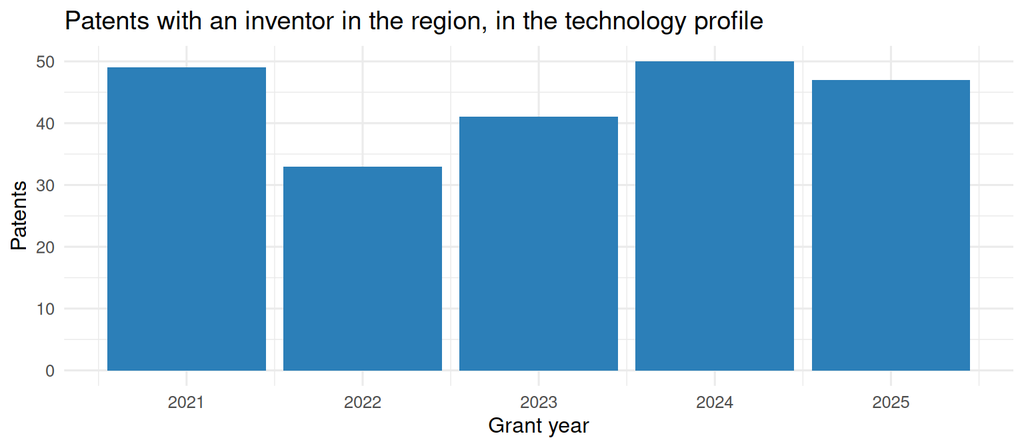

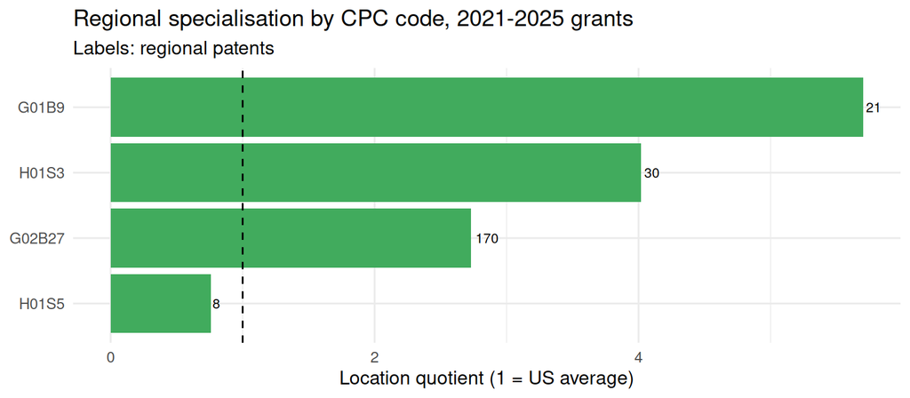

| Assignee | Regional patents in profile |
| --- | --- |
| Vuzix Corporation | 35 |
| CORNING INCORPORATED | 34 |
| University of Rochester | 20 |
| RAYTRX, LLC | 15 |
| Navitar, Inc. | 10 |
| Magic Leap, Inc. | 6 |
| Attochron, LLC | 5 |
| Corning Incorporated | 5 |
| LMD Applied Science, LLC | 5 |
| II-VI DELAWARE, INC. | 4 |

Partner-owned patents invented in the region: 1625, of which 68 (4.2%) fall in the Engine’s technology profile.

## Competition

With 220 patents in the technology profile (2021-2025 grants), the Engine’s region would rank **14** among US states; its specialisation (LQ) is 2.792.

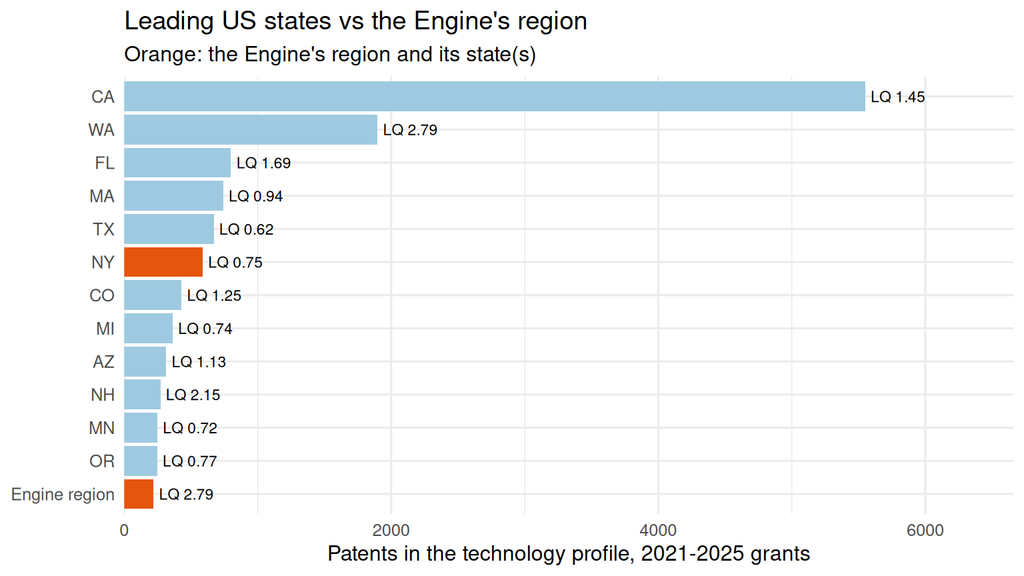

| Country | Share of US patents in profile | Share of world papers in topics |
| --- | --- | --- |
| US | 42.6% | 10.3% |
| JP | 19.5% | 5.4% |
| CN | 8.0% | 35.2% |
| KR | 7.5% | 2.5% |
| TW | 6.0% | 1.9% |
| DE | 5.5% | 5.3% |
| IL | 3.0% | NA |
| GB | 2.7% | 3.3% |
| CA | 2.4% | 1.4% |
| FR | 1.7% | 3.9% |

Patents: inventor countries on US grants in the profile (a patent counts for every country of its inventors). Papers: author countries of OpenAlex works in the Engine’s topics since the window start.

## Data and limitations

- People: PIs and Co-PIs from the NSF Award API; leadership listed on the Engine’s website. Roles come from titles and organisations, revised with OpenAlex evidence.
- Partners: as listed on the Engine’s website, plus organisations of team members. Some Engines publish partner logos without names.
- Region: the Engine’s counties where the list is known (NEO-SMART: 18 Northeast Ohio counties; STELLAR: 11 counties from the NSF abstract), otherwise its states (state-level proxy).
- Technology profile: v3.1 (switch versions in the header). Partner papers and regional patents depend on it: v1 uses mostly CPC subclasses, the v3.1 core uses CPC main groups, which are narrower, so it counts fewer patents and the LQ of a small region rests on few patents.
- Papers: OpenAlex; partner papers are restricted to the Engine’s OpenAlex topics.
- Patents: USPTO grants 2021-2025; inventor locations from PatentsView; pre-grant publications are not included.